# Premiers pas en classification binaire: analyse discriminante linéaire (LDA), "Bayesien naïf" et Régression Logistique

Authors: Alexandre Gramfort, Joseph Salmon

```python
%matplotlib inline
```

Notations pour la classification binaire:

- $\mathcal{Y}$ est l'espace des étiquettes (labels en Anglais), on utilisera $\mathcal{Y} = \{-1,1\}$ en classification binaire,
- $\mathbf{x} = (x_1,\dots,x_p) \in \mathcal{X}\subset \mathbb{R}^p$ est une observation, un échantillon, (un sample en Anglais),
- $ \mathcal{D}_n = \{(\mathbf{x}_i , y_i), i=1,\dots n\}$ est l'ensemble d'apprentissage contenant $n$ échantillons et les étiquettes associées,
- il y a un modèle probabiliste qui gouvene la génération des données $X$ et $Y$: $$ \forall i \in \{1,\dots,n\}, (\mathbf{x}_i , y_i) \stackrel{i.i.d }{\sim} (X,Y)$$.
- L'objectif est d'estimer à partir de données $ \mathcal{D}_n $ une fonction $\hat{f}:\mathcal{X} \mapsto \{-1,1\}$ qui pour un échantillon inconnu $\mathbf{x}$ (i.e. non-présent dans l'ensemble d'apprentissage) peut predire son étiquette : $\hat{f}(\mathbf{x})$.

### Distribution Gaussienne

On dit que $X$ suite une loi Gaussienne en dimension $p$, de centre le vecteu $\mu$ et de covariance la matrice $\Sigma$, ce que l'on note $X\sim\mathcal{N}_p(\mu, \Sigma)$ si la densité du vecteur $X$ est donnée par la fonction: $$ f(\mathbf{x}) = \frac{1}{(2\pi)^{p/2} \sqrt{\det(\Sigma)}} \exp\left\{ -\frac{1}{2} (\mathbf{x}-\mu)^\top \Sigma^{-1} (\mathbf{x}-\mu)\right\}~. $$ Rappel: la matrice de covariance d'un vecteur aléatoire $X$ est définie par $\Sigma = \mathbb{E} \bigl[ (X-\mathbb{E}(X)) (X-\mathbb{E}(X))^\top)\bigr]$.

#### Cas 1D

```python
import numpy as np
import matplotlib.pyplot as plt
```

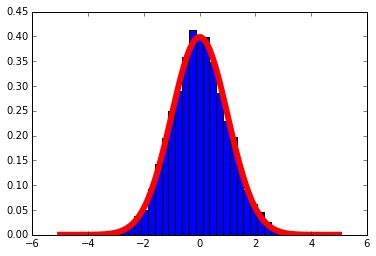

```python
a = np.random.randn(10000)
plt.hist(a, normed=True, bins=30);
t = np.linspace(-5, 5, 100)
plt.plot(t, 1. / np.sqrt(2 * np.pi) * np.exp(-t**2 / 2), 'r', linewidth=6);
```

#### cas 2D

```python
sigma1 = [[1, 0], [0, 1]]
np.array(sigma1)
```

```
array([[1, 0],
       [0, 1]])
```

```python
mu = [2, 2]
sigma1 = [[1, 0], [0, 1]]
sigma2 = [[4, 0], [0, 1]]
sigma3 = [[1, .8], [.8, 1]]

X = np.random.multivariate_normal(mu, sigma1, size=2000)
print X.shape
```

```
(2000, 2)
```

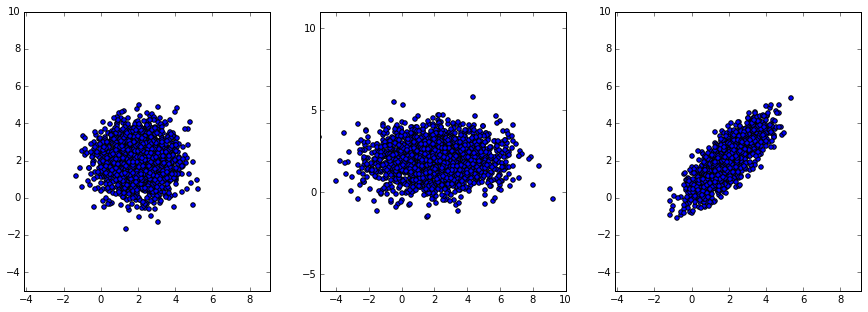

```python
fig, axes = plt.subplots(1, 3, figsize=(15, 5))

for ax, sigma in zip(axes, [sigma1, sigma2, sigma3]):
    X = np.random.multivariate_normal(mu, sigma, size=2000)
    ax.scatter(X[:, 0], X[:, 1])
    ax.axis('equal')
    ax.set_xlim([-5, 10])
    ax.set_ylim([-5, 10])
```

## Modèles Génératifs

Probabilité conditionelle:

$$ f_k(x) = \mathbb{P}\{x | y = k\} $$

Probabilité d'être dans la classe k: $$ \mathbb{P}\{y = k\} = \pi_k $$

Modèle de mélange: $$ \mathbb{P}\{x\} = \sum_{k \in \{-1, 1\}} \pi_k f_k(x) $$

Règle de Bayes: $$ \mathbb{P}\{y=k | x\} = \frac{\mathbb{P}\{y = k\} \mathbb{P}\{x | y = k\}}{\mathbb{P}\{x\}} = \frac{\pi_k f_k(x)}{\sum_{k' \in \{-1, 1\}} \pi_{k'} f_{k'}(x)} $$

### Analyse Discriminante Linéaire (en anglais: Linear Discriminant Analysis, LDA)

Hypothèses de LDA:

$$ \mathbb{P}\{x | y=1\} = \mathcal{N}_p(\mu_1, \Sigma) $$$$ \mathbb{P}\{x | y=-1\} = \mathcal{N}_p(\mu_{-1}, \Sigma) $$

i.e. les densités conditionelles sont Gaussiennes avec la **même covariance** et des **centres differents** pour chaque classe.

Rem: attention en anglais LDA renvoie aussi au concept "Latent Dirichlet Allocation" qui n'a rien à voir...

#### Exemple en dimension 2:

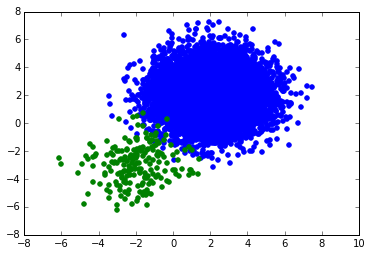

```python
# Generation de donnees selon le modèles génératif ci-dessus
mu1 = [2, 2]
mu2 = [-2, -3]
sigma = [[2, 0], [0, 2]]

X1 = np.random.multivariate_normal(mu1, sigma, size=10000)
X2 = np.random.multivariate_normal(mu2, sigma, size=200)

plt.scatter(X1[:, 0], X1[:, 1], color='b')
plt.scatter(X2[:, 0], X2[:, 1], color='g');
```

Log ratio des probabilités a posteriori de chaques classes:

$$ \log \left(\frac{\mathbb{P}\{Y=+1 \mid X=\mathbf{x}\}}{\mathbb{P}\{Y=-1 \mid X=\mathbf{x}\}}\right) = x^T \Sigma^{-1} (\mu_{1} - \mu_{-1}) + \frac{1}{2} (\mu_{1}^T \Sigma^{-1} \mu_{1} - \mu_{-1}^T \Sigma^{-1} \mu_{-1}) + \log(\frac{\pi_{1}}{\pi_{-1}}) $$

Fonction de décision:

\begin{align} \mathbb{P}\{Y=+1 \mid X=\mathbf{x}\} > \mathbb{P}\{Y=-1 \mid X=\mathbf{x}\} &\Leftrightarrow x^T \Sigma^{-1} (\mu_{1} - \mu_{-1}) + \frac{1}{2} (\mu_{1}^T \Sigma^{-1} \mu_{1} - \mu_{-1}^T \Sigma^{-1} \mu_{-1}) + \log(\frac{\pi_{1}}{\pi_{-1}}) > 0 \\ &\Leftrightarrow y = 1 \quad \text{(au point }\mathbf{x}) \end{align}

C'est **linéaire** (enfin affine) en fonction de $\mathbf{x}$ !!!

### Exemple

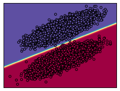

```python
from sklearn.lda import LDA

def demo_clf(clf, X, y, proba=False):
    clf.fit(X, y)

    h = .02  # step size in the mesh
    # Plot the decision boundary. For that, we will assign a color to each
    # point in the mesh [x_min, m_max]x[y_min, y_max].
    x_min, x_max = X[:, 0].min() - .5, X[:, 0].max() + .5
    y_min, y_max = X[:, 1].min() - .5, X[:, 1].max() + .5
    xx, yy = np.meshgrid(np.arange(x_min, x_max, h), np.arange(y_min, y_max, h))
    if proba:
        Z = clf.predict_proba(np.c_[xx.ravel(), yy.ravel()])[:, 1]
    else:
        Z = clf.predict(np.c_[xx.ravel(), yy.ravel()])

    # Put the result into a color plot
    Z = Z.reshape(xx.shape)
    plt.figure(1, figsize=(4, 3))
    cmap = plt.cm.Spectral
    plt.pcolormesh(xx, yy, Z, cmap=cmap, clim=[0, 1])

    # Plot also the training points
    plt.scatter(X[:, 0], X[:, 1], c=y, edgecolors='k', cmap=cmap)

    plt.xlim(xx.min(), xx.max())
    plt.ylim(yy.min(), yy.max())
    plt.xticks(())
    plt.yticks(())

mu1 = [2, 2]
mu2 = [2, -3]
sigma = [[1, 0.8], [0.8, 1]]

X1 = np.random.multivariate_normal(mu1, sigma, size=10000)
X2 = np.random.multivariate_normal(mu2, sigma, size=10000)

X = np.r_[X1, X2]
y = np.array([1] * len(X1) + [-1] * len(X2))

clf = LDA()
demo_clf(clf, X, y, proba=True)
```

## Analyse Discriminante Quadratique (en anglais: Quadratic discriminant analysis, QDA)

Hypothèses de l'Analyse Discriminante Quadratique (QDA):

$$ \mathbb{P}\{x | y=1\} = \mathcal{N}_p(\mu_1, \Sigma_{1}) $$$$ \mathbb{P}\{x | y=-1\} = \mathcal{N}_p(\mu_{-1}, \Sigma_{-1}) $$

i.e. les covariances peuvent changer selon les classes cette fois.

La conséquence est que la frontière entre classes / la fonction de décision est **quadratique**.

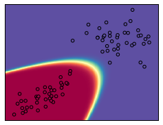

```python
from sklearn.qda import QDA

mu1 = [2, 2]
mu2 = [-2, -3]
sigma1 = [[1, 0], [0, 1]]
sigma2 = [[1, 0.8], [0.8, 1]]

X1 = np.random.multivariate_normal(mu1, sigma1, size=40)
X2 = np.random.multivariate_normal(mu2, sigma2, size=40)
X = np.r_[X1, X2]
y = np.array([1] * len(X1) + [-1] * len(X2))

demo_clf(QDA(), X, y, proba=True)
```

## Modèle Bayésien Naïf (en anglais: Naive Bayes)

Naive Bayes est aussi un modèle **generatif**. Il fait cependant l'hypothèse que toutes les variables explicatives (features) sont independentes conditionnellement à $y$.

$$ \mathbb{P}\{x | y=k\} = \prod_{i=1}^p \mathbb{P}\{x_i | y=k\} $$

### Probabilités conditionelles:

Dans ce cas les probabilité conditionelles se factorisent aisement variable par variable, ce qui permet une bonne efficacité numérique:

$$ \mathbb{P}\{x_i | y=k\} = \frac{1}{(2\pi)^{1/2} \sigma_i^k} \exp \left\{ -\frac{ (x_i-\mu_i^k)^2}{2 (\sigma_i^k)^2}\right\}~. $$

Comme les variances dépendent des classes, on a de nouveau une fonction de décision quadratique.

Rem: on peut comparer le nombre de paramètres qui contrôlent le modèle QDA et le modèle Naif Bayes; l'un est quadritque en $p$, l'autre est linéaire en $p$. C'est une raison qui explique pourquoi le Naif Bayes est plus rapide.

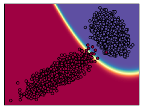

```python
from sklearn.naive_bayes import GaussianNB

mu1 = [2, 2]
mu2 = [-2, -3]
sigma1 = [[0.3, -0.2], [-0.2, 1]]
sigma2 = [[1, 0.8], [0.8, 1]]

X1 = np.random.multivariate_normal(mu1, sigma1, size=2000)
X2 = np.random.multivariate_normal(mu2, sigma2, size=2000)
X = np.r_[X1, X2]
y = np.array([1] * len(X1) + [-1] * len(X2))

demo_clf(GaussianNB(), X, y, proba=True)
```

#### Question :

Puis-je estimer un Naive Bayes avec en entrée un flux continu de données?

## Régression Logistique

La régression logistique est une méthode **discriminatif** pour la classification (bien que le nom soit régression...)

Le modèle est le même que LDA avec un log ratio qui est une fonction linéaire des features:

$$ \log \left(\frac{\mathbb{P}\{Y=+1 \mid X=\mathbf{x}\}}{\mathbb{P}\{Y=-1 \mid X=\mathbf{x}\}}\right) = x^T \beta + \beta_0 $$

Fonction de décision **linéaire**:

$$ x^T \beta + \beta_0 > 0 \Rightarrow y = 1 $$

Probabilités conditionelles:

En pratique $\beta$ et $\beta_0$ sont calculés en maximisant la vraisemblance des données d'apprentissage. Cela donne:

$$ \hat{\beta}, \hat{\beta}_0 = {\rm argmax}_{\beta, \beta_0} \sum_{i=1}^n \sum_k 1_{\{Y_i = k\}} \log (\mathbb{P}\{Y=k \mid X=\mathbf{x}_i, \beta, \beta_0 \}) $$

On peut montrer que cela donne (avec la convention y=1 ou y=-1):

$$ \hat{\beta}, \hat{\beta}_0 = {\rm argmax}_{\beta, \beta_0} \sum_{i=1}^n \log \{1 + \exp(-y_i(\mathbf{x}_i^T \beta + \beta_0) \}) $$

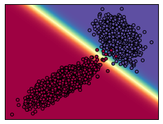

```python
from sklearn.linear_model import LogisticRegression

X1 = np.random.multivariate_normal(mu1, sigma1, size=2000)
X2 = np.random.multivariate_normal(mu2, sigma2, size=2000)
X = np.r_[X1, X2]
y = np.array([1] * len(X1) + [-1] * len(X2))

demo_clf(LogisticRegression(), X, y, proba=True)
```

```python
LogisticRegression?
```

## Traitement d'interactions d'ordre 2 avec la Régression Logistique

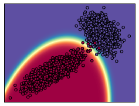

```python
from sklearn.preprocessing import PolynomialFeatures

def demo_clf(clf, X, y, proba=False):
    clf.fit(PolynomialFeatures(2).fit_transform(X), y)

    h = .02  # step size in the mesh
    # Plot the decision boundary. For that, we will assign a color to each
    # point in the mesh [x_min, m_max]x[y_min, y_max].
    x_min, x_max = X[:, 0].min() - .5, X[:, 0].max() + .5
    y_min, y_max = X[:, 1].min() - .5, X[:, 1].max() + .5
    xx, yy = np.meshgrid(np.arange(x_min, x_max, h), np.arange(y_min, y_max, h))
    XX = PolynomialFeatures(2).fit_transform(np.c_[xx.ravel(), yy.ravel()])
    if proba:
        Z = clf.predict_proba(XX)[:, 1]
    else:
        Z = clf.predict(XX)

    # Put the result into a color plot
    Z = Z.reshape(xx.shape)
    plt.figure(1, figsize=(4, 3))
    cmap = plt.cm.Spectral
    plt.pcolormesh(xx, yy, Z, cmap=cmap, clim=[0, 1])

    # Plot also the training points
    plt.scatter(X[:, 0], X[:, 1], c=y, edgecolors='k', cmap=cmap)

    plt.xlim(xx.min(), xx.max())
    plt.ylim(yy.min(), yy.max())
    plt.xticks(())
    plt.yticks(())

demo_clf(LogisticRegression(), X, y, proba=True)
```